# Assignment Three : Technical Report

Ghazal Ayobi and Shah Ali Gardezi

2/15/2022

## Summary

The aim of this project is to build a model to predict fast growth firms using the Bisnode firms data. In order to build the model we used the mentioned datasheet which contains detailed information about all middle sized registered European companies. The data set contains detailed description of the companies from 2005-2016 for some industries like manufacturing(Electronic and optical, Electrical Equipment, machinery) and services(accommodation, and food and average service activities). In this project we focus on the cross-section of the companies in 2012 whether they have fast growing or no. The Business Question we would ask is whether these companies had fast growth in two subsequent years or no. The prediction for this project was built on several characteristics of the companies such financial, profit and loss statement, balance sheet, and firm features. The main aim of this case study is to build a classification model to differentiate between fast and non-fast growing firms. We used 7 different models including OLS, LASSO, Random Forest and OLS logit. As result of the above model the best selected model was Model 3 with RMSE of 0.361 and AUC was 0.6576 and the average expected loss was 0.3076. Moreover, we the best selected model for both services and Manufacture where we received the following results. The main aim of the project is to choose a prediction model which assists the decision makers on their investment in a company. Moreover, we also checked the selected our model performance for manufacturing and service industries. For the manufacturing industry the RMSE was 0.3771520, AUC was 0.6413224 and average expected loss was 0.3338673. For the service industry the RMSE is 0.344, AUC is 0.691 and the expected loss is 0.273

## Introdction

This study focuses on the firms from 2010 to 2015 mainly the firms had high growth rate from 2012 to 2014. In order to classify firms as fast growing and not fast growing we minimized the average expected loss and applied the appropriate threshold to assist investment decisions. Moreover, the main aim of this case study is to build a prediction model which can support individuals in their investment decisions in choosing between fast and non-fast growing firms. To classify firms in the mentioned categories, we need a loss function which quantifies the consequences of the decisions that are driven by the prediction (Gabors, 2021). The loss function has two values, one is a loss due to the false negative and a loss due to the false positive. For this purpose we considered these features of the companies and build 7 different models which are OLS, LASSO, Random Forest and OLS Logit. The data comes form the Bisnode, a company that offers decision support in forms of digital business, marketing and credit information. The data set contains detailed description of the companies from 2005-2016 for some industries in manufacturing and services. In this study we focus on the cross section of the companies in 2012, we will ask weather they are fast growing or not in the subsequent years.

## Label Engineering

Before start of modeling it is vital to define our *y* variable and start with feature engineering. Based on the Business question we would to build a model to predict fast and non-fast growing firms. Thus, it is important to define what is considered as fast growing firm. For this purpose we consider CAGR, To start with label engineering we define *y* variable which is whether a company is a fast growing or non-fast growing. Thus, we use compound annual growth rate (CAGR) to be 28% or more. The reason is that on average small or mid-size firms in their initial years have higher annual growth rate than the large companies. Thus, in order to consider a small or mid-size firm as fast growing, we expect it to have CAGR of 28% or more across two years. Thus we define fast growing firms if their CAGR sales value is 28% or more for this purpose we are focusing on the mid and small size firms we only kept the sales between 10 million and 1000 euros.

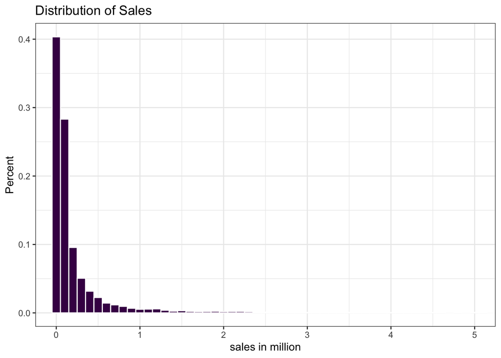

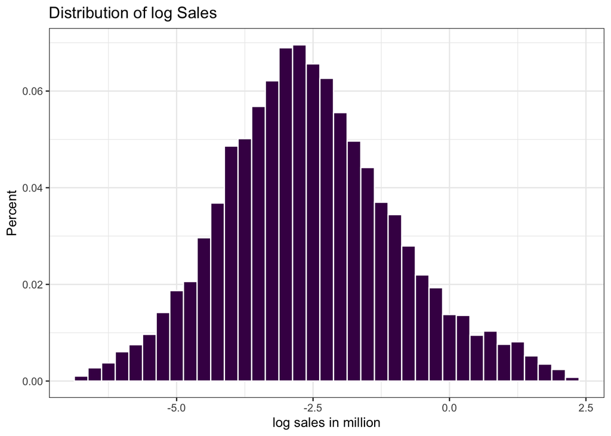

As the above graph shows that the distribution of sales is skewed to the right and log of sales has a close to normal distribution.

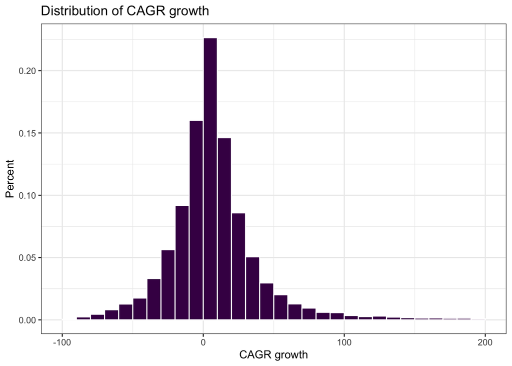

## Feature Engineering

The third task in the case study is feature engineering, which consists of selecting *x* variables, cleaning them and putting them in appropriate forms for the prediction model. The variables have different characteristics such about the firm which are the firm size, financial factors, human resource and others. The main part of feature engineering is to decide what functional forms of variables should be included. Some of the variables are as following:

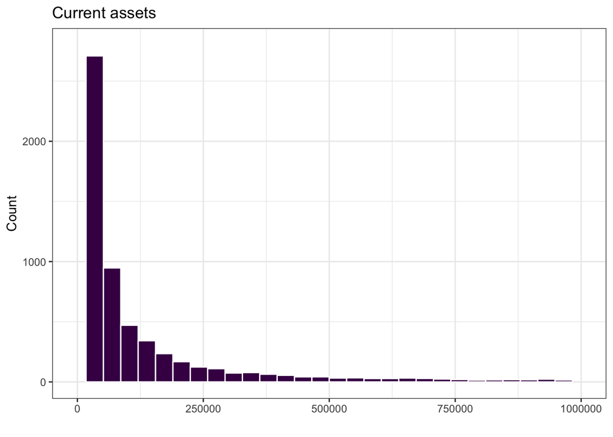

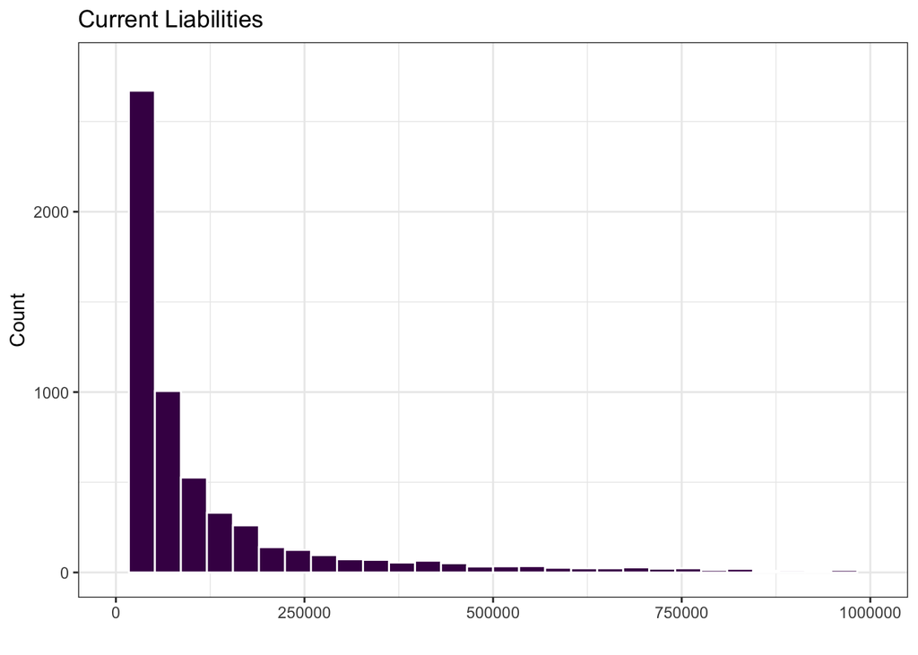

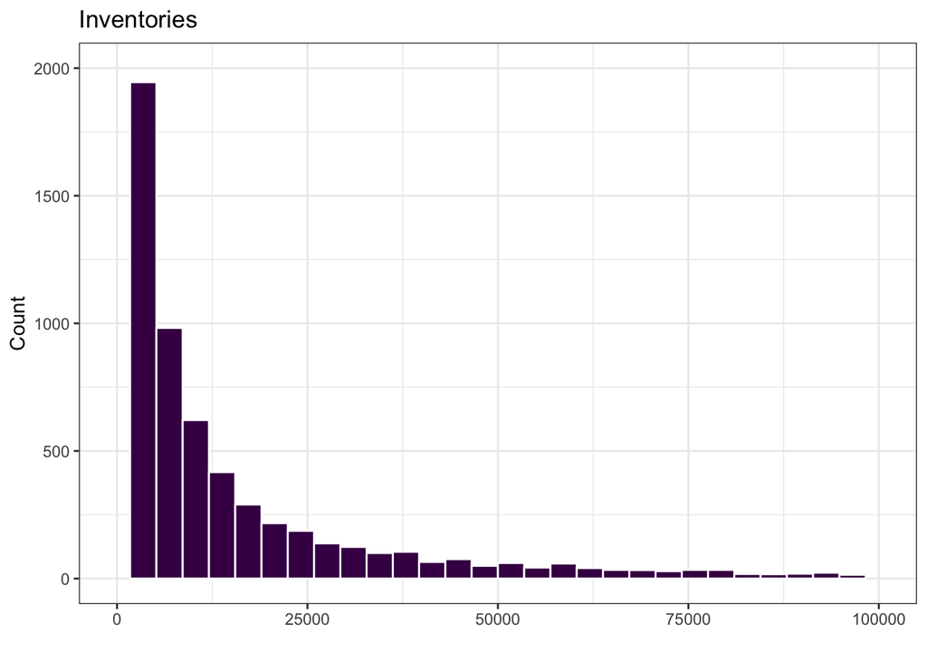

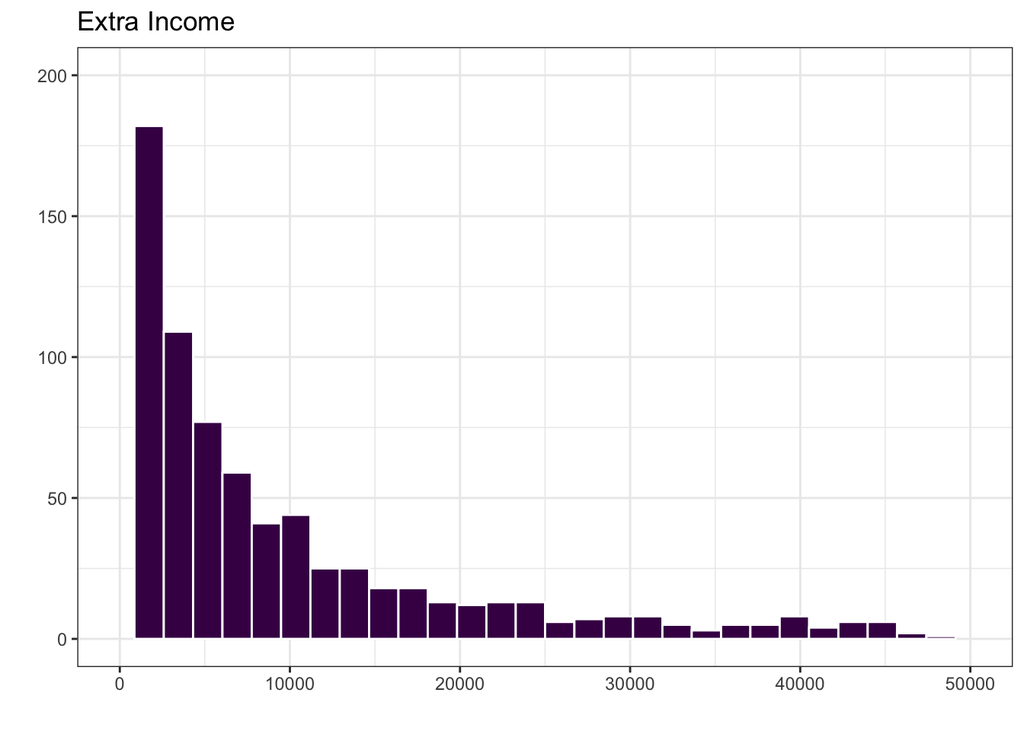

The above figure shows that most of the variables from the data set have skewed distribution. there are a wide range of potential extreme values which also contains errors and unusual values. It is vital to check the distribution of main variables before assigning a functional form. There are various ways to address such values. Such as: grouping the factor variables, transforming the function to its logarithmic form and another method used by the Gabor, 2021 is winsorization. which states that it is a process where for each variable we identify a threshold value and replace values outside that threshold with threshold values itself and adding a flag variables. Thus, we created some new variables based on the result of the distribution of the main financial variables. For example, different types of assets are expected to be positive, thus, we added flag asset to identify assets more than zero. Moreover, we assigned zero for all the assets intangible, current and fixed, for less than negative values. Moreover, we created new columns for all the profit and loss variables and scaled them by dividing the variables by sales and we created another balance sheet ratio variables by dividing the variables on total assets. Moreover, as these ratios contains variation thus, based on the firms nature and we winsorized them and keep the ratios between -1 and 1. Moreover, we also identify counting variables which cannot be less than zero and created a flag variable as *flag_error* to identify such values. In addition, we created a balance sheet variable which sums all of the total assets. To capture non-linearity we also added some variables in the square and quadratic terms.

The curve below shows the relationship between income before taxes and the fast and non fast growing firms.

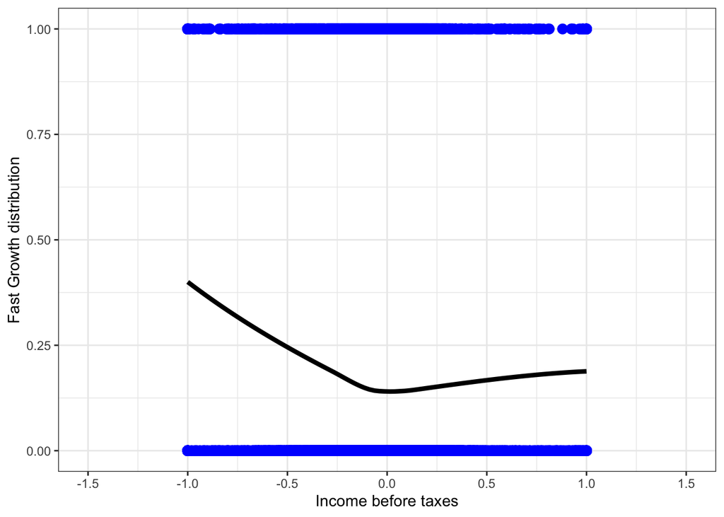

Other flag variables were created to identify the age of CEU of the firm and other variables such as type of industry were transformed to the factors and as result missing variables were addressed in multiple ways such as imputation, dropping. as a result of data cleaning, munging, imputation, and removing null variables, we have 10462 observations and 117 variables.

# Modeling

Based on the defined business question the main aim of this project is to build a prediction model to identify fast and non-fast growing firms. For this purpose we use compound annual growth rate with a threshold of 28% over the period of two years 2012 to 2014. Based on the business question we identify the firms as fast growing which performs more than the above growth rate. The table below shows that based on define criteria 16.5% of the firms have fast growth rate. The reason behind considering two years interval from 2012 to 2014. it is difficult to identify firms as fast and not fast growing based on the coverage of one year. Two years gives a more detailed and cumulative growth rate for the considered firms. As the firms grow they maitain their growth from the first year to the second, thus, two year sales CAGR is taken to identify fast growing firms.

Firm Growth Summary

| Growth | N | Percent |
| --- | --- | --- |
| no_fast_growth | 8736 | 83.50 |
| fast_growth | 1726 | 16.50 |

## Set up

The best model gives the best prediction in the live data. Before turning to the modeling part of the project, it is worth mentioning that in order to avoid over fitting, the original data is split into two random parts by 20% to 80% ratio. Holdout set contains the 20% and the rest is work data set. For the training set we use 5-fold cross validation, this means splitting the train data into five random samples and calculating and deciding based on the average of 5 CV RMSE result.

## Probability Prediction and Model selection

### Probability Logit Models

|  | Number.of.predictors | CV.RMSE | CV.AUC |
| --- | --- | --- | --- |
| X1 | 11 | 0.3652356 | 0.6175837 |
| X2 | 18 | 0.3632548 | 0.6385690 |
| X3 | 35 | 0.3614056 | 0.6576329 |
| X4 | 78 | 0.3619492 | 0.6577036 |
| X5 | 152 | 0.3647497 | 0.6544113 |

### LASSO MODEL

|  | Number.of.predictors | CV.RMSE | CV.AUC |
| --- | --- | --- | --- |
| X3 | 35 | 0.3614056 | 0.6576329 |
| LASSO | 73 | 0.3611901 | 0.6404095 |

### Random Forest

For this case study the last model is (probability) Random Forest using the set of variables for the random forest from the model section. These variables are raw variables, human resource, and firm variables. Moreover, the variables in the random forest does not have any patterns because Random forest can assign functional forms and interactions. We set the random forest tuning parameter to be either 5, 6, or 7 in each split. The result from the Random Forest indicates that (probability) Random Forest outperforms other models such as LASSO and probability logit by around -0.001 RMSE and the AUC result is higher than the both mentioned model 3 and LASSO logit. As a result the Random Forest based on the RMSE and AUC result is the best performing model. Thus, we use our holdout set to draw ROC curve.

|  | CV.RMSE | CV.AUC |
| --- | --- | --- |
| X3 | 0.3614056 | 0.6576329 |
| Random_forest | 0.3606019 | 0.6715044 |

### ROC Curve

The ROC curve is a widely used tool that graphically presents the trade-off between false positive and false negative that arise when we apply different classification thresholds to the probability predictions from an estimated model. Moreover, the ROC curve shows false positive among all y = 0 observations and and the proportion of the true positive among all y = 1 observations. (Gabors, 2021). Thus, we draw the ROC curve for the selected model which is the Rnadom Forest. Below are the two versions of the ROC curve. The ROC curve points for the various thresholds show the values between 0.05 and 0.75 by steps of 0.025. The mentioned curve also utilizes color coding to show the approximate values of the related threshold, as of the moment the point are not shown. The below curve on the below right is similar to common ROC curve. The main important point in this curve is it fill in for the threshold values, however it does not have any points to indicate the threshold values. Based on the result from our best model of Random Forest its AUC is 0.67. A higher threshold means fewer false positive or fewer true positive, on the other hand, a lower threshold indicates more true positive and more false positive. Thus, by looking to the below curves, we require to set a threshold, for which we need to create the loss function.

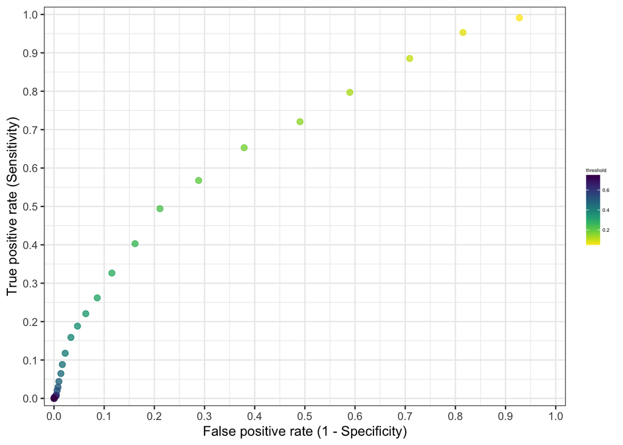

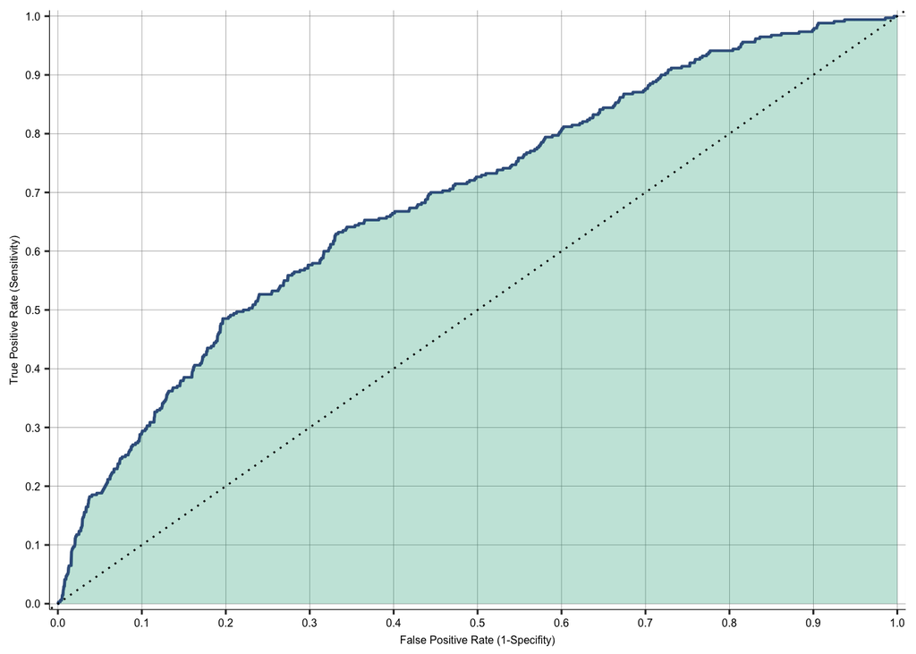

### Finding the Optimal Classification Threshold

The last part of this case study is to define the loss function. Loss function quantifies the consequences of decisions that are driven by prediction(Gabors, 2021). While classification if binary y variable we can be wrong in two places for false negative classification FN, or making a false positive classification FP. At this point a loss function have only two values, one is a loss due to false negative and the other is loss due to false positive. Based on the previous models we define the loss function as following. It is worth mentioning that we require the loss function to assist decision making. The main goal od this study is to build a model to identify fast growing farms. With the mentioned models we require to find the threshold value for the classification which will result in the smallest expected loss which is called Optimal classification threshold which is shown as following.

$$optimal-classification-threshold = \frac{loss(FP)}{loss(FP) + loss(FN)}$$

$$OCT = \frac{1}{1+2} = 0.333$$

|  | Number.of.predictors | CV.RMSE | CV.AUC | CV.threshold | CV.expected.Loss |
| --- | --- | --- | --- | --- | --- |
| Logit X1 | 11 | 0.3652356 | 0.6175837 | 0.3084928 | 0.3178006 |
| Logit X3 | 35 | 0.3614056 | 0.6576329 | 0.3819412 | 0.3076450 |
| Logit LASSO | 73 | 0.3611901 | 0.6404095 | 0.3702485 | 0.3196050 |
| RF probability | 36 | 0.3606019 | 0.6715044 | 0.3672268 | 0.3083616 |

## Best Model based on Expected Loss

# Model Evaluation and Confusion Matrix

As we have chosen our best model, we can evaluate the result. As a result we can say that we correctly predicted 83% of the firms. he The accuracy of the model is 83% the model classified correctly 83% of the firms. The specificity of the model is 97% which indicates that from not fast growing firms the model correctly estimated 97%. The sensitivity of the model is 11% which means the model predicted the fast growing firms by 11%.

|  | no_fast_growth | fast_growth |
| --- | --- | --- |
| no_fast_growth | 1705 | 302 |
| fast_growth | 47 | 38 |

$$accuracy = \frac{TP + TN}{N} = \frac{1705+38} {2092} = 83\%$$
$$sensitivity = \frac{TP}{TP + FN} = \frac{38} {38 + 302} = 11\%$$
$$specifcity = \frac{TN}{TN + FP} = \frac{1705} {1705 + 47} = 97\%$$

## Industry Analysis

| Column.1 | Column.2 | Column.3 |
| --- | --- | --- |
| Prediction | Refrence non fast growing | Refrence fast growing |
| Prediction Non fast growing | 590 | 142 |
| Prediction fast growing | 26 | 16 |

$$accuracy = \frac{TP + TN}{N} = \frac{590+16} {774} = 78\%$$
$$sensitivity = \frac{TP}{TP + FN} = \frac{16} {16 + 142} = 10\%$$

$$specifcity = \frac{TN}{TN + FP} = \frac{590} {590 + 26} = 95\%$$
The next industry is service industry which contains 6591 observation and 117 columns. The service data set has 5589 non fast growing firms which is around 84% of the service firms, moreover the number of fast growing firms are 1002 which is 15.2% of the all fast growing firms. Moreover we used Confusion table on holdout with optimal threshold for the services the result for the confusion Matrix is the following table. Moreover the accuracy of service industry is 83%. The sensitivity of the service industry using the optimal threshold is 10% and the specificity is 96%.

| Column.1 | Column.2 | Column.3 |
| --- | --- | --- |
| Prediction | Refrence non fast growing | Refrence fast growing |
| Prediction Non fast growing | 1081 | 181 |
| Prediction fast growing | 34 | 22 |

$$accuracy = \frac{TP + TN}{N} = \frac{22+1081} {1318} = 83\%$$
$$sensitivity = \frac{TP}{TP + FN} = \frac{22} {22 + 181} = 10\%$$
$$specifcity = \frac{TN}{TN + FP} = \frac{1081} {1081 + 34} = 96\%$$
As a result we can say that based on the accuracy of the model across whole data set and sub sets of manufacturing and services, The complete data set has same accuracy as service industry meaning they classify the right category 83%. However, the manufacturing industry only classified 78% of the firms correctly. The second measurement is sensitivity which is the proportion of true positives among all actual positives. In this case study sensitivity is the actual fast growing firms. Based on the Confusion table on holdout with optimal threshold in main dataset, in the two sub sets of service and manufacture industries, the actual data set predicted 11% of the actual fast growing firms and the other two sub groups performed the same and predicted 10% of the actual fast growing firms. The third classification measurement in the data set is specificity. It means predicting the non fast firms correctly is highest in the main data set, services, and finally manufacturing industry, with specificity of 97%, 96%, and 95% consecutively. As a result the service industry performed better compared to the manufacture industry.

| Name | Number.of.predictors | CV.RMSE | CV.AUC | CV.threshold | CV.expected.Loss |
| --- | --- | --- | --- | --- | --- |
| Logit 1 | 9 | 0.3797699 | 0.6189397 | 0.3171125 | 0.3377388 |
| logit 3 | 33 | 0.3771520 | 0.6413224 | 0.3900734 | 0.3338673 |
| Lasso | 57 | 0.3774197 | 0.6255187 | 0.4201095 | 0.3478465 |
| Random Forest | 36 | 0.3762268 | 0.6584220 | 0.3401336 | 0.3335447 |

| Name | Number.of.predictors | CV.RMSE | CV.AUC | CV.threshold | CV.expected.Loss |
| --- | --- | --- | --- | --- | --- |
| Logit 1 | 5 | 0.3503573 | 0.6455616 | 0.3370839 | 0.2875045 |
| logit 3 | 29 | 0.3445528 | 0.6913800 | 0.3961532 | 0.2730912 |
| Lasso | 48 | 0.3452804 | 0.6720352 | 0.4331575 | 0.2892485 |
| Random Forest | 36 | 0.3455207 | 0.6922673 | 0.4034729 | 0.2806748 |

## Summary

The final model which was chosen for this case study was Model 3 which has the variable of firm details and engine variables which are firm financial information of balance sheet and profit and loss. The The accuracy of the model is 83% the model classified correctly 83% of the firms. The specificity of the model is 97% which indicates that from not fast growing firms the model correctly estimated 97%. The sensitivity of the model is 11% which means the model predicted the fast growing firms. The result is a helpful tool for the firms to predict which firms are fast and non fast growing. Moreover, we compared across industry result considering the same single loss function and carrying out the exercise for different industries. All result were predicted based on the logit model 3. The performance of whole data and all models were evaluated.